# Homework 1

Ngoc Anh Nguyen

3/31/2020

This raport contains the results of research on repreduction of 3 articles about R packages:`TP.idm`, `InfoTrad` and `picasso`.

## 1) `TP.idm`package: Probabilities for the Illness-Death Model

The [article](https://www.jstatsoft.org/article/view/v083i10/v83i10.pdf) can be found in Journal of Statistical Software. The package is available from the Comprehensive R Archive Network, [CRAN](https://cran.r-project.org/web/packages/TP.idm/index.html)

**Short description**

*An R package by Vanesa Balboa and Jacobo de Uña-Álvarez from Universidade de Vigo to compute an empirical transition probability matrix for the illness-death model. This package implements a novel non-parametric estimator which is particularly well suited for non-Markov processes observed under right censoring. Variance estimates and confidence limits are also implemented inthe package.*

**Installation**

```r
install.packages("TP.idm")
```

The installation was successful and very fast.

**Application to real data**

There was a section in the article to illustrate how to use the functions available in the package TP.idm. Our task was to reproduce the results of any code chunk and generate visualisations as the ones presented.

```r
#setting mirrors
options(repos=structure(c(CRAN="https://cran.cnr.berkeley.edu/")))

data("colonTP", package = "TP.idm")
colonTP[1:6, 1:5]
```

```
##   time1 event1 Stime event      rx
## 1   968      1  1521     1 Lev+5FU
## 2  3087      0  3087     0 Lev+5FU
## 3   542      1   963     1     Obs
## 4   245      1   293     1 Lev+5FU
## 5   523      1   659     1     Obs
## 6   904      1  1767     1 Lev+5FU
```

```r
library(TP.idm)
nm01 <- TPidm(colonTP, s = 0, t = 365)
nm01
```

```
## Call:
## TPidm(data = colonTP, s = 0, t = 365)
##
## Parameters:
## s= 0
## t= 365
## Method= NM
## CI= TRUE
## CI transformation= linear
## Possible transitions:
## [1] "1 1" "1 2" "1 3"
##
## Occupation probabilities at time t:
##
##
##  transition      probs      lower     upper     variance
##         1 1 0.75242196 0.72469972 0.7801442 2.000600e-04
##         1 2 0.16361679 0.14032419 0.1869094 1.412342e-04
##         1 3 0.08396125 0.06611612 0.1018064 8.289786e-05
```

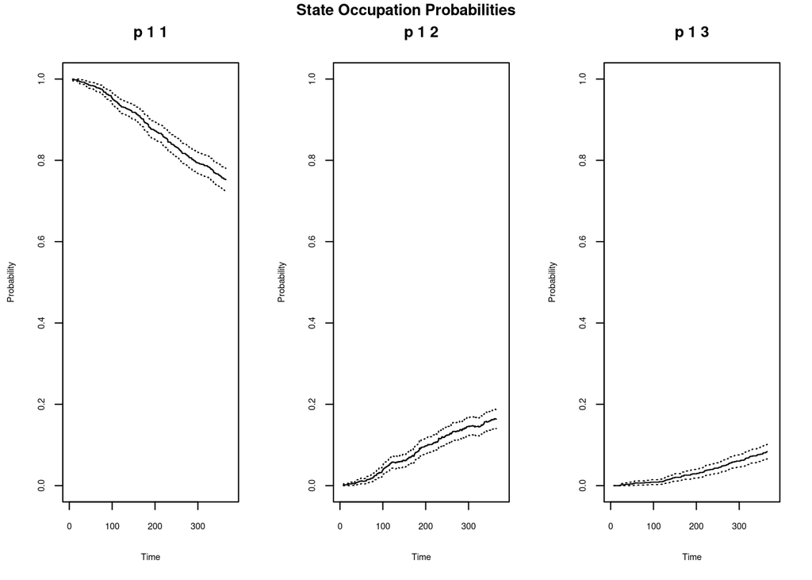

```r
# figure 1
plot(nm01)
```

```r
nm01$all.probs[seq(1, 194, length.out = 5), 1, ]
```

```
##      trans
## rows        1 1         1 2        1 3
##   8   0.9989236 0.001076426 0.00000000
##   122 0.9311087 0.058127018 0.01076426
##   204 0.8697524 0.100107643 0.03013994
##   279 0.8073197 0.136706136 0.05597417
##   365 0.7524220 0.163616792 0.08396125
```

```r
nm01$all.probs[nm01$times == 122, 1:4, ]
```

```
##           trans
## cols                1 1          1 2          1 3
##   probs    9.311087e-01 5.812702e-02 1.076426e-02
##   lower    9.148379e-01 4.313396e-02 4.125039e-03
##   upper    9.473795e-01 7.312008e-02 1.740349e-02
##   variance 6.891647e-05 5.851734e-05 1.147462e-05
```

```r
nm02 <- TPidm(colonTP, s = 0, t = 730)
nm12 <- TPidm(colonTP, s = 365, t = 730)
nm02
```

```
## Call:
## TPidm(data = colonTP, s = 0, t = 730)
##
## Parameters:
## s= 0
## t= 730
## Method= NM
## CI= TRUE
## CI transformation= linear
## Possible transitions:
## [1] "1 1" "1 2" "1 3"
##
## Occupation probabilities at time t:
##
##
##  transition     probs     lower     upper     variance
##         1 1 0.5994026 0.5679173 0.6308878 0.0002580580
##         1 2 0.1744163 0.1511832 0.1976494 0.0001405136
##         1 3 0.2261811 0.1992494 0.2531128 0.0001888131
```

```r
nm12
```

```
## Call:
## TPidm(data = colonTP, s = 365, t = 730)
##
## Parameters:
## s= 365
## t= 730
## Method= NM
## CI= TRUE
## CI transformation= linear
## Possible transitions:
## [1] "1 1" "1 2" "1 3" "2 2" "2 3"
##
## Transition probabilities at time t:
##
##
##  transition     probs      lower      upper     variance
##         1 1 0.7966309 0.76680585 0.82645591 2.315611e-04
##         1 2 0.1475010 0.12166865 0.17333340 1.737131e-04
##         1 3 0.0558681 0.03881836 0.07291783 7.567264e-05
##         2 2 0.3881579 0.31125428 0.46506151 1.539563e-03
##         2 3 0.6118421 0.53493849 0.68874572 1.539563e-03
```

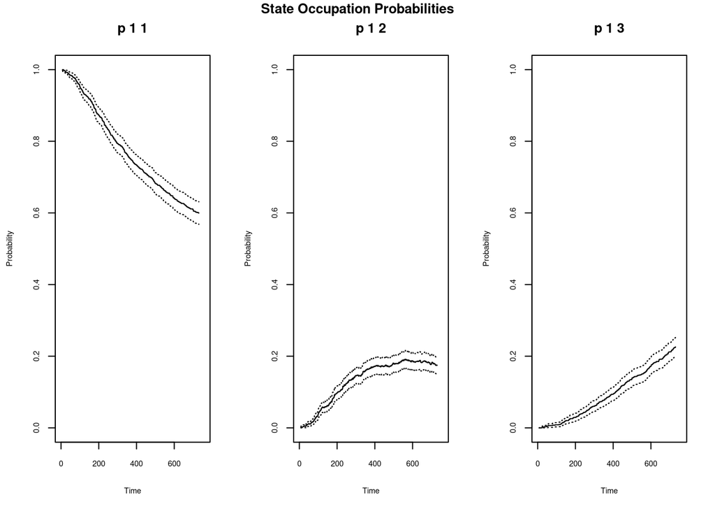

```r
plot(nm02)
```

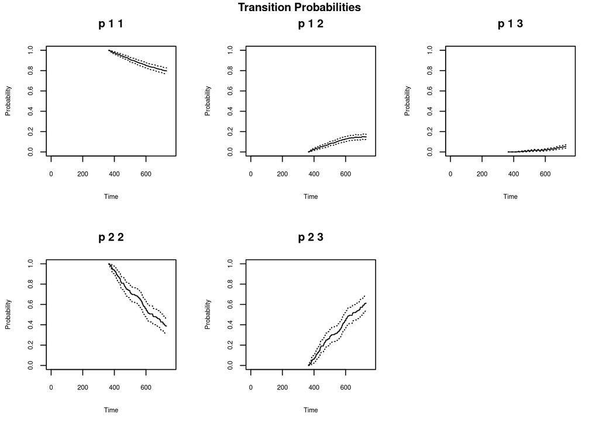

```r
plot(nm12)
```

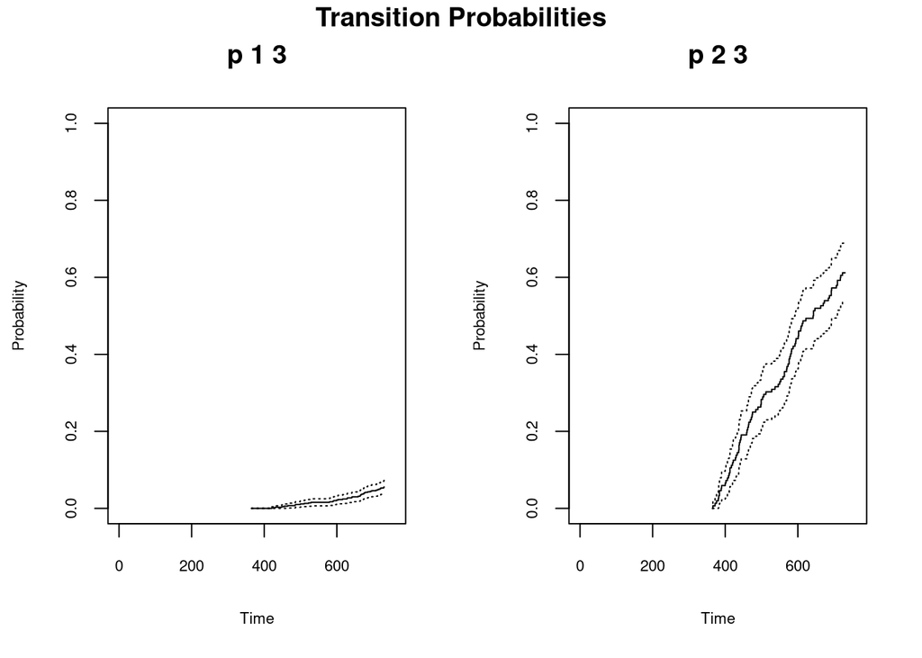

```r
# figure 2
plot(nm12, chosen.tr = c("1 3", "2 3"))
```

```r
nm0t_rx <- TPidm(colonTP, s = 0, cov = "rx")
nm0t_rx
```

```
## Call:
## TPidm(data = colonTP, s = 0, cov = "rx")
##
## Parameters:
## s= 0
## t:
## $t
## [1] 2789
##
## $t
## [1] 2910
##
## $t
## [1] 2725
##
##
## Covariate= rx
## Method= NM
## CI= TRUE
## CI transformation= linear
## Possible transitions:
## [1] "1 1" "1 2" "1 3"
##
## Occupation probabilities at time t:
##
##
## $probs
## $probs$Obs
##          probs     lower     upper    variance
## 1 1 0.34172071 0.2615270 0.4219144 0.001674112
## 1 2 0.06601195 0.0000000 0.1399636 0.001423638
## 1 3 0.59226734 0.5129924 0.6715423 0.001635973
##
## $probs$Lev
##           probs     lower      upper     variance
## 1 1  0.40430442 0.3481828 0.46042609 0.0008199076
## 1 2 -0.01181462 0.0000000 0.04125536 0.0007331651
## 1 3  0.60751020 0.4922649 0.72275546 0.0034574024
##
## $probs$`Lev+5FU`
##          probs     lower     upper     variance
## 1 1 0.53837372 0.4746374 0.6021101 0.0010574952
## 1 2 0.02226273 0.0000000 0.0682034 0.0005494124
## 1 3 0.43936355 0.3718034 0.5069237 0.0011881873
```

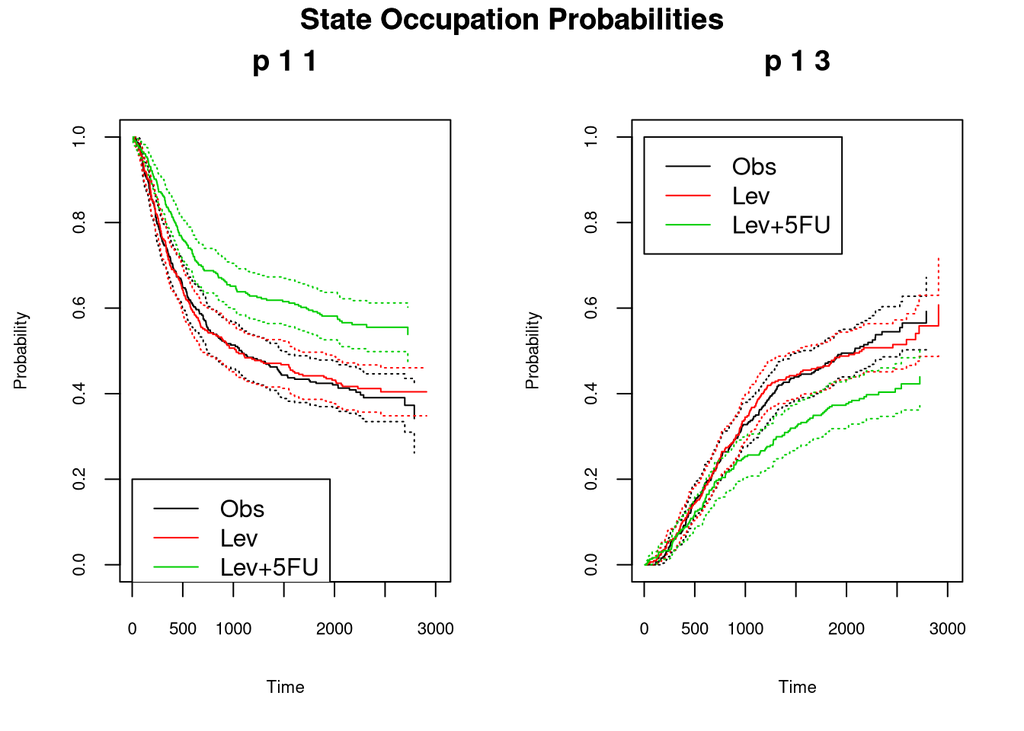

```r
# figure 3
plot(nm0t_rx, chosen.tr = c("1 1"), col = 1:3)
legend(0, 0.2, legend = c("Obs", "Lev", "Lev+5FU"), lty = 1, col = 1:3)

# figure 4
plot(nm0t_rx, chosen.tr = c("1 3"), col = 1:3)
legend(0, 1, legend = c("Obs", "Lev", "Lev+5FU"), lty = 1, col = 1:3)
```

```r
# figure 5
test.nm(colonTP[colonTP$rx == "Obs", ], s = 365)
```

```
## Parameters:
## s= 365
## t= 2789
```

```r
colonTP$entrytime <- colonTP$time1

install.packages("survival")
library(survival)
```

[figure not shown]

```r
coxph(Surv(time1, Stime, event) ~ entrytime, data = colonTP[colonTP$time1 < colonTP$Stime & colonTP$rx == "Obs", ])
```

```
## Call:
## coxph(formula = Surv(time1, Stime, event) ~ entrytime, data = colonTP[colonTP$time1 <
##     colonTP$Stime & colonTP$rx == "Obs", ])
##
##                 coef  exp(coef)   se(coef)      z     p
## entrytime -0.0005275  0.9994726  0.0002826 -1.867 0.062
##
## Likelihood ratio test=3.53  on 1 df, p=0.06029
## n= 177, number of events= 155
```

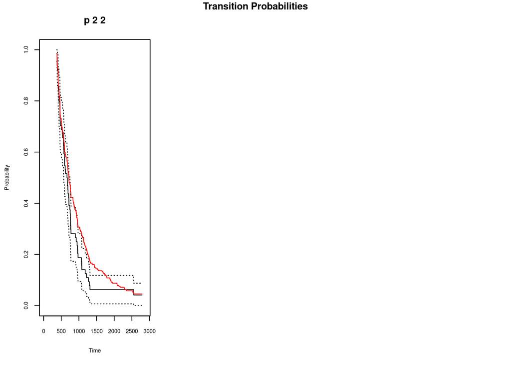

```r
# figure 6
plot(TPidm(colonTP[colonTP$rx == "Obs",], s = 365), chosen.tr = c("2 2"))
aj1t.Obs <- TPidm(colonTP[colonTP$rx == "Obs",], s = 365, method = "AJ")
lines(aj1t.Obs$times, aj1t.Obs$all.probs[ , 1, 4], type = "s", col = 2)
```

**Results**

This article’s code outputs and charts are 100% reproducible.

## 2) `InfoTrad`: : An R package for estimating the probability of informed trading

The [article](https://journal.r-project.org/archive/2018/RJ-2018-013/index.html) can be found in R Journal.

**Short description**

The R package InfoTrad provides five different functions: - `EHO()`, - `LK()`, - `YZ()`, - `GAN()`, - `EA()`.

*The first two functions provide likelihood specifications whereas the last three functions can be used to obtain parameter estimates for Θ to calculate PIN in equation (3). All five functions require a data frame that contains Bt in the first column, and St in the second column. We create Bt and St for ten hypothetical trading days.*

**Installation**

```r
install.packages("InfoTrad")
```

The installation was successful and very fast.

**Sample data**

```r
library(InfoTrad)
# Sample Data
Buy<-c(350,250,500,552,163,345,847,923,123,349)
Sell<-c(382,500,463,550,200,323,456,342,578,455)
data=cbind(Buy,Sell)

# Initial parameter values
# par0 = (alpha, delta, mu, epsilon_b, epsilon_s)
par0 = c(0.5,0.5,300,400,500)
```

### `EHO()` function

```r
# Call EHO function
EHO_out = EHO(data)
model = optim(par0, EHO_out, gr = NULL, method = c("Nelder-Mead"), hessian = FALSE)

## Parameter Estimates
model$par[1] # Estimate for alpha
```

```
## [1] -216494.4
```

```r
model$par[2] # Estimate for delta
```

```
## [1] 631863.4
```

```r
model$par[3] # Estimate for mu
```

```
## [1] 380.386
```

```r
model$par[4] # Estimate for eb
```

```
## [1] 307.447
```

```r
model$par[5] # Estimate for es
```

```
## [1] 435.555
```

```r
## Estimate for PIN
(model$par[1]*model$par[3])/((model$par[1]*model$par[3])+model$par[4]+model$par[5])
```

```
## [1] 1.000009
```

Estimates differ.

### `LK()` function

```r
# Call LK function
LK_out = LK(data)
model = optim(par0, LK_out, gr = NULL, method = c("Nelder-Mead"), hessian = FALSE)

## The structure of the model output
model
```

```
## $par
## [1] -1.188082e+08  2.107302e+08  4.416373e+02  2.663480e+02  4.374163e+02
##
## $value
## [1] -44639.23
##
## $counts
## function gradient
##      502       NA
##
## $convergence
## [1] 1
##
## $message
## NULL
```

```r
model$par[1] # Estimate for alpha
```

```
## [1] -118808167
```

```r
model$par[2] # Estimate for delta
```

```
## [1] 210730213
```

```r
model$par[3] # Estimate for mu
```

```
## [1] 441.6373
```

```r
model$par[4] # Estimate for eb
```

```
## [1] 266.348
```

```r
model$par[5] # Estimate for es
```

```
## [1] 437.4163
```

```r
## Estimate for PIN
(model$par[1]*model$par[3])/((model$par[1]*model$par[3])+model$par[4]+model$par[5])
```

```
## [1] 1
```

Estimates differ.

### `YZ()` function

```r
# Parameter estimates using the LK factorization of Lin and Ke (2011)
# with the algorithm of Yan and Zhang (2012).
# Default factorization is set to be "LK"
result=YZ(data)
print(result)
```

[output not shown]

```r
# Parameter estimates using the EHO factorization of Easley et. al. (2010)
# with the algorithm of Yan and Zhang (2012).
result=YZ(data,likelihood="EHO")
print(result)
```

[output not shown]

The results are identical as in article.

### `GAN()` function

```r
# Parameter estimates using the LK factorization of Lin and Ke (2011)
# with the algorithm of Gan et. al. (2015).
# Default factorization is set to be "LK"
result=GAN(data)
print(result)
```

```
## Alpha: 0.3999998
## Delta: 0
## Mu: 442.1667
## Epsilon_b: 263.3333
## Epsilon_s: 424.9
## Likelihood Value: 44371.84
## PIN: 0.2044464
```

```r
# Parameter estimates using the EHO factorization of Easley et. al. (2010)
# with the algorithm of Gan et. al. (2015)
result=GAN(data, likelihood="EHO")
print(result)
```

```
## Alpha: 0.3230001
## Delta: 0.4780001
## Mu: 481.3526
## Epsilon_b: 356.6359
## Epsilon_s: 313.136
## Likelihood Value: Inf
## PIN: 0.1884001
```

The results are identical as in article.

### `EA()` function

```r
# Parameter estimates using the LK factorization of Lin and Ke (2011)
# with the modified clustering algorithm of Ersan and Alici (2016).
# Default factorization is set to be "LK"
result=EA(data)
print(result)
```

```
## Alpha: 0.9511418
## Delta: 0.2694005
## Mu: 76.7224
## Epsilon_b: 493.7045
## Epsilon_s: 377.4877
## Likelihood Value: 43973.71
## PIN: 0.07728924
```

```r
# Parameter estimates using the EHO factorization of Easley et. al. (2010)
# with the modified clustering algorithm of Ersan and Alici (2016).
result=EA(data,likelihood="EHO")
print(result)
```

```
## Alpha: 0.9511418
## Delta: 0.2694005
## Mu: 76.7224
## Epsilon_b: 493.7045
## Epsilon_s: 377.4877
## Likelihood Value: 43973.71
## PIN: 0.07728924
```

The results are identical as in article.

**Results** First two functions’ output (EHO and LK) were different from article.

*“We define EHO() and LK() as simple likelihood specifications rather than functions that execute the MLE procedure. This is due to the fact that MLE estimators vary depending on the optimization procedure. Users who wish to develop alternative estimation techniques, based on the proposed likelihood factorization, can use EHO() and LK(). This is the underlying reason why those functions do not have built-in optimization procedures.”*

## 3) `picasso` package

The [article](http://www.jmlr.org/papers/volume20/17-722/17-722.pdf) can be found in Journal of Machine Learning Research. More details can be found in [Github page](https://github.com/jasonge27/picasso).

**Short description**

*The library by Jason Ge, Xingguo Li, Haoming Jiang, Han Liu, Tong Zhang, Mengdi Wang Tuo Zhao implements a unified framework of pathwise coordinate optimization for a variety of sparse learning problems (e.g., sparse linear regression, sparse logistic regression, sparse Poisson regression and scaled sparse linear regression) combined with efficient active set selection strategies.*

**Installation**

```r
install.packages("picasso")
```

The installation was successful abd very fast.

**Example of R User Interface**

```r
library(picasso);
```

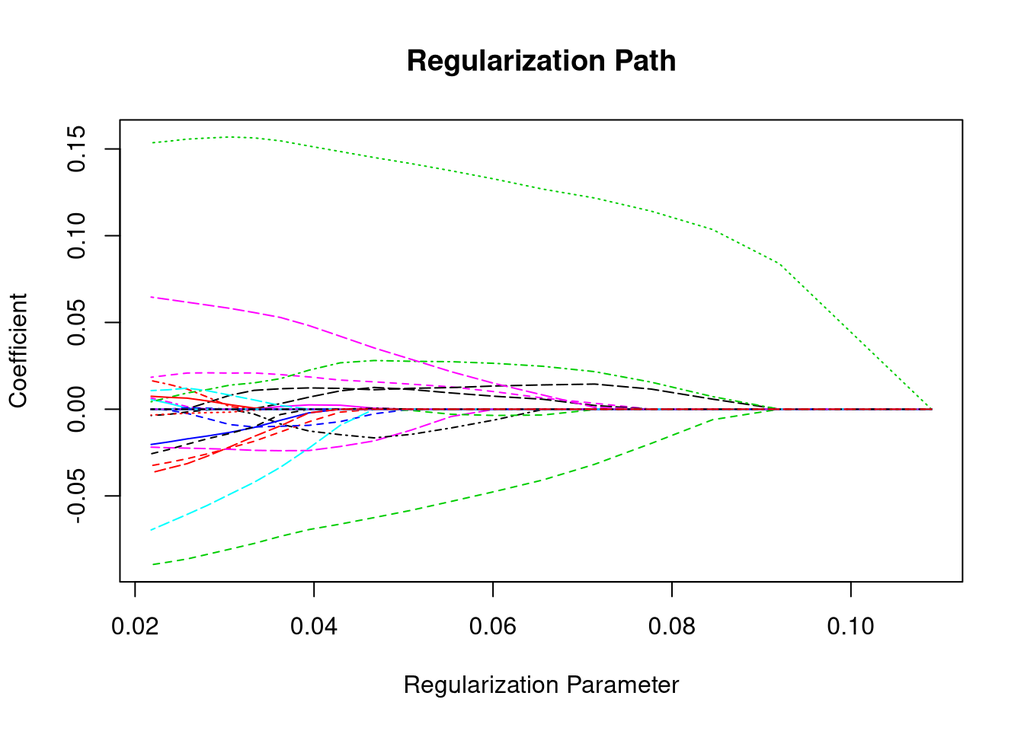

```r
# Load the data set
data(eyedata)
# Lasso
out1 = picasso(x,y,method="l1",type.gaussian="naive",nlambda=20, lambda.min.ratio=0.2)
# MCP regularizer
out2 = picasso(x,y,method="mcp", gamma = 1.25, prec=1e-4)

# Plot solution paths
plot(out1)
```

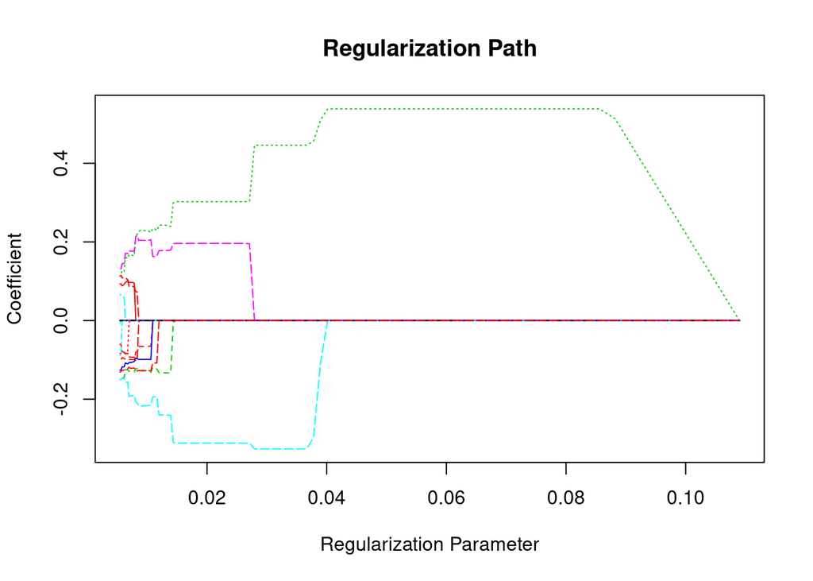

```r
plot(out2)
```

**Results** The output is 100% reproducible.